# viewport

## Notes

### devicePixelRatio

#### `devicePixelRatio` is not simulated

Follow [#7075](https://github.com/cypress-io/cypress/issues/7075) if you need this supported.

### Restores

#### Cypress will restore the viewport in the snapshot

When hovering over each command, Cypress will automatically display the snapshot in the viewport dimensions that existed when that command ran.

### Defaults

#### Default sizing

By default, until you issue a `cy.viewport()` command, Cypress sets the width to `1000px` and the height to `660px` by default.

You can [change these default dimensions](https://docs.cypress.io/guides/references/configuration#Viewport) by adding the following to your configuration file (`cypress.json` by default):

```json
{
  "viewportWidth": 1000,
  "viewportHeight": 660
}
```

Additionally, Cypress automatically sets the viewport to its default size between each test.

### Scaling

#### Auto Scaling

By default, if your screen is not large enough to display all of the current dimension's pixels, Cypress will scale and center your application within the Cypress runner to accommodate.

Scaling the app should not affect any calculations or behavior of your application (in fact it won't even know it's being scaled).

The upsides to this are that tests should consistently pass or fail regardless of a developers' screen size. Tests will also consistently run in `CI` because all of the viewports will be the same no matter what machine Cypress runs on.

### Reset viewport via `Cypress.config()`

You can change the size of the viewport height and width for the remainder of the tests by setting the new values for `viewportHeight` or `viewportWidth` within Cypress.config().

```javascript
Cypress.config('viewportWidth', 800)
Cypress.config('viewportWidth') // => 800
```

### Set viewport in the test configuration

You can configure the size of the viewport height and width within a suite or test by passing the new configuration value within the [test configuration](https://docs.cypress.io/guides/references/configuration#Test-Configuration).

This will set the height and width throughout the duration of the tests, then return it to the default `viewportHeight` and `viewportWidth` when complete.

```javascript
describe(
  'page display on medium size screen',
  {
    viewportHeight: 1000,
    viewportWidth: 400,
  },
  () => {
    it('does not display sidebar', () => {
      cy.get('#sidebar').should('not.be.visible')
    })

    it('shows hamburger menu', () => {
      cy.get('#header').find('i.menu').should('be.visible')
    })
  }
)
```

## Rules

### Requirements

- `cy.viewport()` requires being chained off of `cy` .

### Assertions

- `cy.viewport()` cannot have any assertions chained.

### Timeouts

- `cy.viewport()` cannot time out.

## Command Log

*Change viewport size to test responsive nav*

```javascript
cy.get('#navbar').should('be.visible')

cy.viewport(320, 480)

// the navbar should have collapse since our screen is smaller
cy.get('#navbar').should('not.be.visible')
cy.get('.navbar-toggle').should('be.visible').click()
cy.get('.nav').find('a').should('be.visible')
```

The commands above will display in the Command Log as:

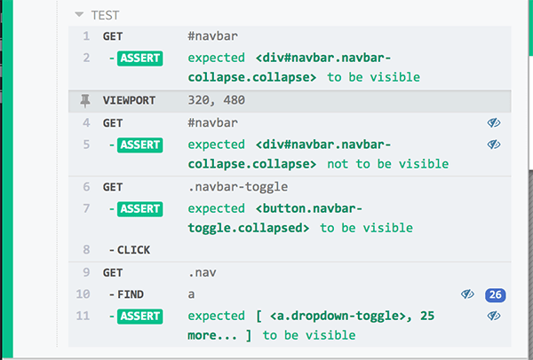

When clicking on `viewport` within the command log, the console outputs the following:

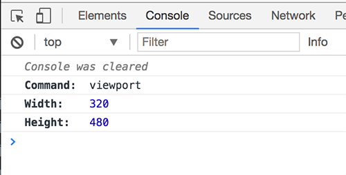

## History

| Version | Changes |
| --- | --- |
| [5.5.0](https://docs.cypress.io/guides/references/changelog#5-5-0) | Added support for `macbook-16` preset. |
| [5.4.0](https://docs.cypress.io/guides/references/changelog#5-4-0) | Added support for presets `iphone-7`, `iphone-8`, and `iphone-se2`. |
| [3.8.0](https://docs.cypress.io/guides/references/changelog#3-8-0) | Removed max viewport size and lowered min viewport size to `0`. |
| [3.5.0](https://docs.cypress.io/guides/references/changelog#3-5-0) | Added support for presets `iphone-xr`, `iphone-x`, `samsung-s10`, and `samsung-note9` |
| [3.5.0](https://docs.cypress.io/guides/references/changelog#3-5-0) | Increased max viewport size to `4000` |
| [0.9.0](https://docs.cypress.io/guides/references/changelog#0-9-0) | `cy.viewport()` command added |

## See also

- Read blog post [Use meaningful smoke tests](https://www.cypress.io/blog/2019/12/06/use-meaningful-smoke-tests/) where we run the same test with different viewport resolutions
- Read blog post [Generate High-Resolution Videos and Screenshots](https://www.cypress.io/blog/2021/03/01/generate-high-resolution-videos-and-screenshots/) to learn how to change the browser's window size to capture screenshots and videos with more detail
- [Configuration](https://docs.cypress.io/guides/references/configuration)
- Cypress.config()

© 2017 Cypress.io  
Licensed under the MIT License.  
https://docs.cypress.io/api/commands/viewport